# NIFTY 50 Return Distribution and Volatility Analysis

## 3.3 Descriptive statistics

Descriptive Statistics of NIFTY 50 Log Returns

| Statistic | Value |
| --- | --- |
| Observations | 4534.000000 |
| Mean | 0.000343 |
| Standard Deviation | 0.013017 |
| Skewness | -0.294100 |
| Excess Kurtosis | 15.152300 |
| Minimum | -0.139000 |
| Maximum | 0.163300 |

The return distribution exhibits **mild negative skewness (−0.29)**, indicating that **downside movements tend to be slightly more pronounced than upward movements.**Market declines may occur more abruptly during periods of stress or uncertainty and risk exposure for investors remains asymmetric.

More significantly, **the series displays extremely high excess kurtosis (≈15.15), reflecting strong fat-tailed behavior and a substantially higher frequency of extreme observations relative to a normal distribution.** It implies large drawdowns and sudden volatility spikes are structurally embedded within the return process.

Together, the presence of negative skewness and extreme kurtosis suggests that the NIFTY 50 exhibits asymmetric downside risk alongside substantial tail risk. **While average daily fluctuations remain relatively small, the market remains vulnerable to infrequent but severe shocks that occur with greater probability than implied by a normal distribution.**

# 4 Distribution analysis

## 4.1 histogram & normality overlay

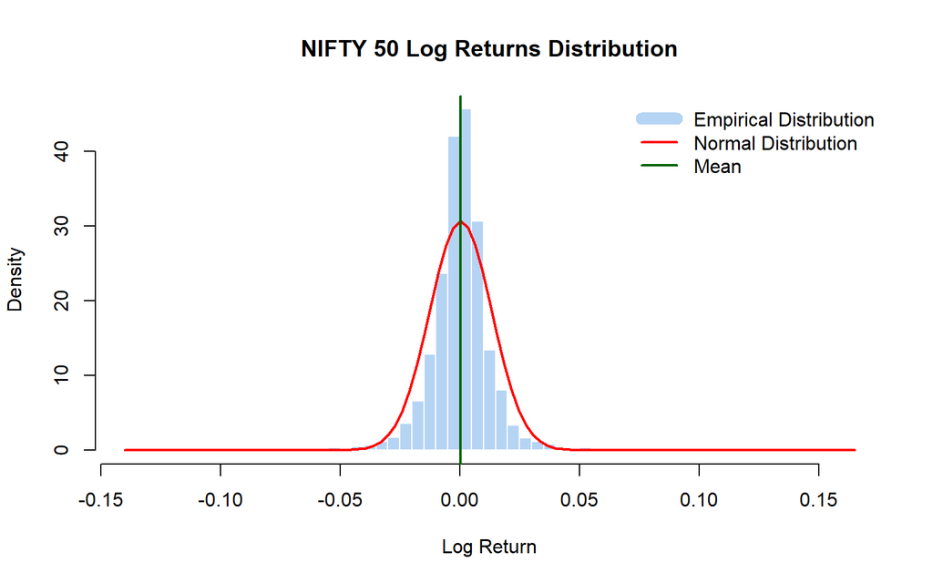

**Key Observations:**

- The return distribution exhibits **leptokurtosis**, indicating excess kurtosis relative to the normal distribution.
- There is a clear **deviation from normality**, as the empirical distribution does not align with the Gaussian benchmark.
- Returns show **strong central clustering**, reflected in a sharper peak around the mean.
- The distribution displays **fat tails**, implying a higher probability of extreme market movements.
- A mild **negative skewness** is observed, suggesting that downside movements are slightly more pronounced than upside movements.

The distribution of NIFTY 50 log returns appears roughly bell-shaped, but it clearly **does not align with a normal distribution.** The center of the histogram is more sharply peaked than the Gaussian curve, suggesting that **a large proportion of returns are concentrated close to the mean.**

At the same time, the tails are noticeably heavier than those of a normal distribution, indicating the presence of **excess kurtosis.** In practical terms, this means that **large market moves—both positive and negative—occur more often than what a normal model would predict.**

There is also a slight asymmetry in the distribution, with a mild negative skew. This suggests that **downward movements tend to be somewhat more pronounced than upward movements,** which is consistent with typical equity market behavior.

**Overall, the pattern reflects a common feature of financial return series: most days see relatively small changes, but these are occasionally interrupted by sharp movements. This deviation from normality is important, as models based on Gaussian assumptions tend to underestimate the likelihood of extreme events.**

## 4.2 Q–Q Plot analysis

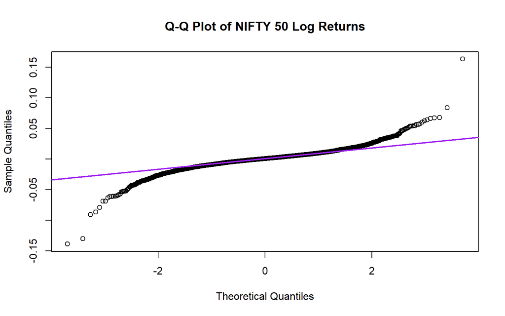

**The Q–Q plot compares the empirical distribution of returns with a theoretical normal distribution.** While the central observations lie reasonably close to the reference line, noticeable deviations occur in the tails.

These deviations indicate that **extreme values are more frequent than would be expected under normality,** providing visual evidence of fat tails. This behavior is **consistent with the presence of excess kurtosis observed earlier.**

## 4.3 Normality test: Jarque-Bera

The Jarque-Bera test is a method for testing if the normality assumption is reasonable

$$H_0 : \text{Returns are normally distributed}$$

$$H_1 : \text{Returns are not normally distributed}$$

**Jarque–Bera Test Results:**  
JB statistic = 4.3438958^{4}  
p-value = 0

**The Jarque–Bera test strongly rejects the null hypothesis (H₀) that NIFTY 50 returns are normally distributed (χ² = 43439, p-value < 2.2e−16).** Consequently, the alternative hypothesis (H₁) is accepted, indicating significant departures from a Gaussian distribution.

The rejection of normality is largely driven by the extreme **excess kurtosis observed in the return series, reflecting the presence of pronounced fat tails and clustered extreme observations. This suggests that large market shocks occur materially more frequently than would be predicted under standard normal assumptions.**

From a market perspective, the findings imply that **tail-risk events and volatility shocks are structurally embedded within the NIFTY 50 return process.**

# 5 Time series properties

## 5.1 Augmented Dickey-Fuller test

The following test determines whether a given time series is stationary.
$$H_0 : \text{Series is non-stationary}$$

$$H_1 : \text{Series is stationary}$$

**ADF Test Results:**  
Test statistic = -15.219  
Reported p-value = 0.01

**The Augmented Dickey–Fuller (ADF) test strongly rejects the null hypothesis of a unit root, indicating that the NIFTY 50 return series is stationary.** The reported p-value of **0.01** represents the lower boundary reported by the test procedure, implying that the **true p-value is less than or equal to 0.01.**

This result suggests that the statistical properties of the return series remain sufficiently stable over time for meaningful time-series and volatility analysis. In practical terms, **while the raw NIFTY 50 price index exhibits long-term trending behavior, the transformed log return series fluctuates around a relatively stable structure suitable for econometric modeling.**

## 5.2 Autocorrelational analysis

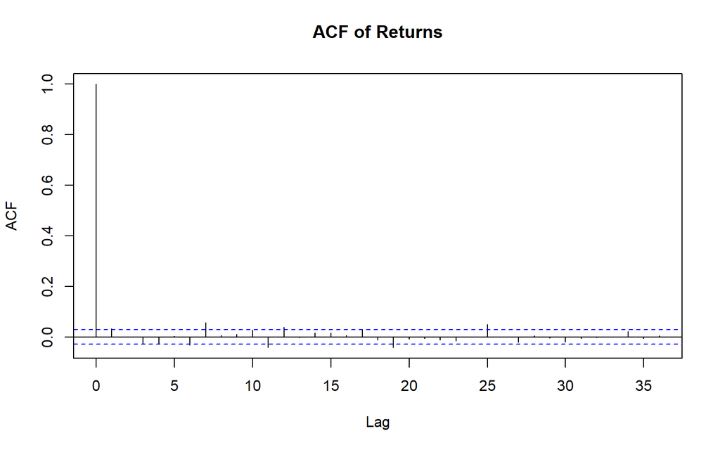

The autocorrelation function (ACF) of NIFTY 50 returns shows that **most autocorrelation coefficients remain close to zero and largely within the 95% confidence bounds, indicating the absence of strong linear dependence in returns.**

Although the Ljung–Box test later detects statistically significant autocorrelation, **the magnitude of the observed dependence remains extremely small. Given the large sample size, even minor deviations from perfect independence become statistically detectable.**

In practical terms, the return process still exhibits **limited exploitable predictability** and remains broadly consistent with **weak-form market efficiency.**

## 5.3 Autocorrelation function of squared returns

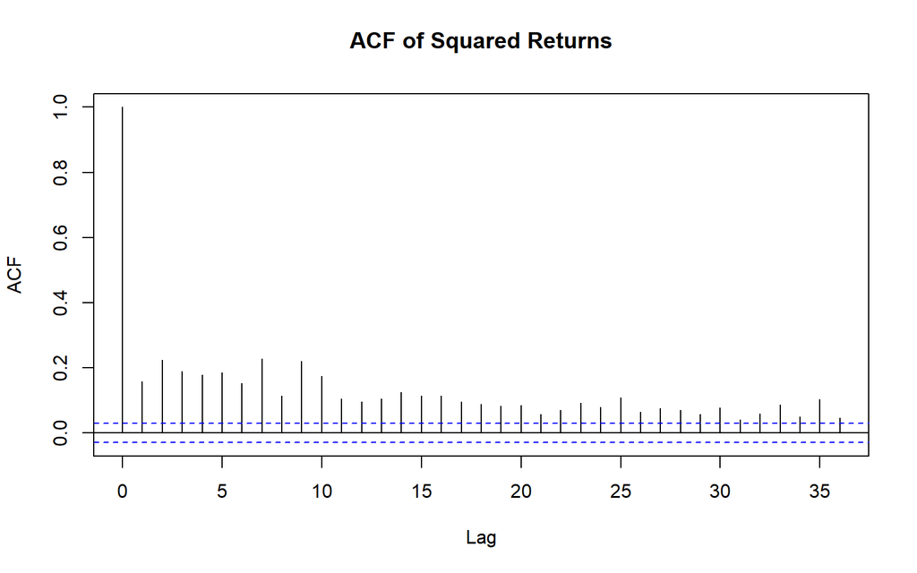

**The ACF of squared returns exhibits significant positive autocorrelation, indicating strong persistence in volatility and clear evidence of volatility clustering within the NIFTY 50.** Periods of elevated market risk tend to be followed by further high-volatility periods, while calmer market phases are followed by relatively stable conditions.

This behavior reflects **heteroscedasticity,** where the **variance of returns changes over time rather than remaining constant.**

In practical market terms, this suggests that **uncertainty and risk in the NIFTY 50 are persistent rather than random.** During periods of macroeconomic stress **heightened volatility tends to sustain itself across multiple trading sessions instead of dissipating immediately.**

## 5.4 Partial autocorrelational function of squared values

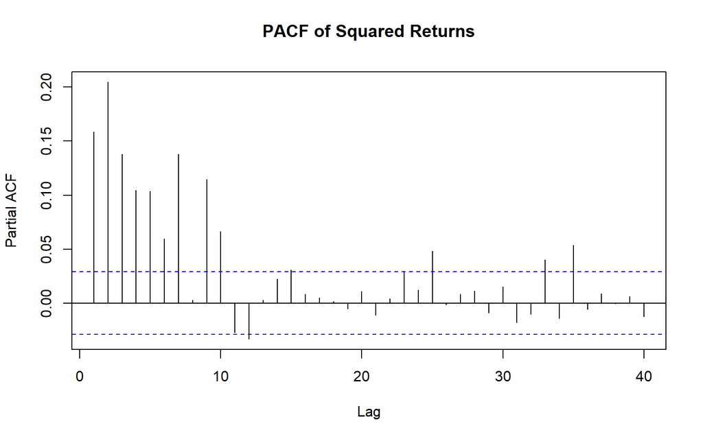

# 6 Hypothesis testing:

## 6.1 Hypothesis 1: Mean Return equals 0 (t-test)

The one-sample t-test examines whether the average daily log return of the NIFTY 50 is statistically different from zero.

$$H_0 : \mu = 0$$

$$H_1 : \mu \neq 0$$

**t-test results:**  
t-statistic = 1.776  
p-value = 0.0759  
Sample mean return = 0.000343

- **The one-sample t-test fails to reject the null hypothesis (H₀)** that the mean daily return of the NIFTY 50 is equal to zero **(p-value = 0.0759).**

$$p = 0.07587 > 0.05$$

- Statistically, the mean return is not significantly different from zero at the 5% significance level. This suggests that **short-term daily returns fluctuate closely around zero without exhibiting a persistent directional drift.**
- **Day-to-day price movements in the NIFTY 50 are largely driven by random market fluctuations rather than predictable excess returns.**

## 6.2 Hypothesis 2: Independence of returns (Ljung-Box test)

The Ljung–Box test is used to determine whether a time series exhibits significant autocorrelation across multiple lags.It evaluates the joint signif icance of autocorrelations collectively.

$$H_0 : \text{No autocorrelation exists (returns are independent)}$$

$$H_1 : \text{Autocorrelation exists}$$

**Ljung–Box Test on Returns:**  
Test statistic = 64.619  
p-value = 1.342^{-6}

**The Ljung–Box test rejects the null hypothesis of no autocorrelation, but, the empirical ACF coefficients remain extremely small in magnitude and largely concentrated within the confidence bounds.** Given the large sample size ($n = 4534$), the Ljung–Box statistic is highly sensitive to even minor deviations from perfect independence.

As a result, **the statistical significance detected by the test does not necessarily imply economically meaningful predictability in returns**. In practical terms, **the observed dependence structure remains weak** and broadly consistent with the notion that **short-term NIFTY 50 returns exhibit limited exploitable linear predictability.**

## 6.3 Ljung–Box Diagnostics on returns and squared Returns

**Ljung–Box Test on Returns:**  
Test statistic = 64.619  
p-value = 1.342^{-6}

**Ljung–Box Test on Squared Returns:**  
Test statistic = 2042.323  
p-value = 0

The Ljung–Box diagnostics reveal a **fundamental asymmetry in the statistical behavior of NIFTY 50 returns and volatility.** While **raw returns exhibit only economically weak autocorrelation** despite statistical significance, **squared returns display extremely strong serial dependence across time.**

This distinction implies that **short-term market direction remains largely difficult to predict, broadly consistent with weak-form market efficiency.** However, market volatility itself exhibits substantial persistence and predictability, indicating that **periods of elevated risk tend to cluster rather than occur randomly.**

In practical terms, the results suggest that **although investors may struggle to consistently forecast whether the market will rise or fall tomorrow, the underlying level of market uncertainty and risk evolves in a highly structured and time-dependent manner.**

## 6.4 Hypothesis 3: Volatility clustering (ARCH Test)

The ARCH (Autoregressive Conditional Heteroscedasticity) test examines whether the variance of returns remains constant over time or changes systematically.

$$H_0 : \text{No ARCH effects exist (constant variance)}$$

$$H_1 : \text{ARCH effects exist (variance is time-varying)}$$

**ARCH LM Test Results:**  
Test statistic = 636.679  
p-value = 1.546^{-128}

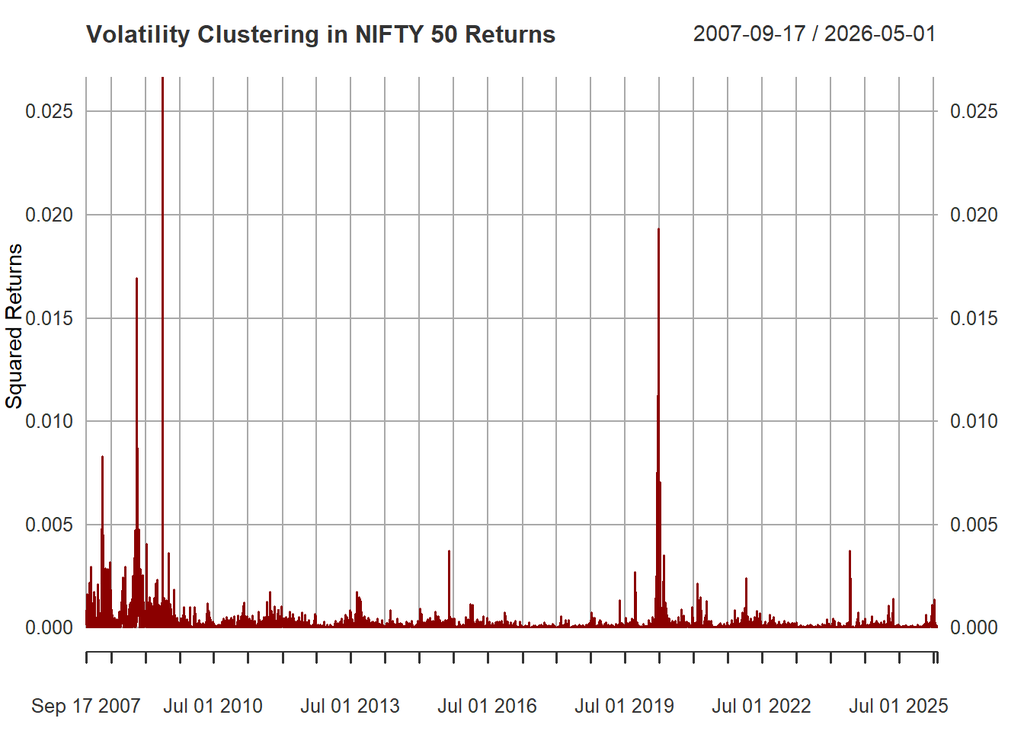

The ARCH LM test strongly rejects the null hypothesis of constant variance, providing **significant evidence of conditional heteroscedasticity** within the NIFTY 50 return series.

In practical terms, **periods of elevated market uncertainty tend to cluster across consecutive trading sessions rather than dissipating immediately after a shock.** Such behavior is characteristic of financial markets, where **large market movements are frequently followed by further periods of heightened volatility.** The presence of significant ARCH effects further suggests that **constant-variance models may inadequately capture the evolving risk dynamics of the NIFTY 50, reinforcing the suitability of conditional volatility frameworks** for modeling market risk and volatility persistence.

The significant ARCH effects confirm that **conditional variance in the NIFTY 50 is time-dependent, with volatility shocks propagating persistently through the return series.**

# 7 Modeling implications for risk estimation

Comparison of Historical and Gaussian Value-at-Risk Estimates

|  | Confidence Level | Historical VaR (%) | Gaussian VaR (%) | Underestimation (%) |
| --- | --- | --- | --- | --- |
| 5% | 95% | -1.87 | -2.11 | 12.72 |
| 1% | 99% | -3.64 | -2.99 | 17.68 |

**This result highlights a key limitation of constant-variance Gaussian frameworks** commonly used in traditional risk management. While such models may approximate average market behavior reasonably well, **they fail to adequately capture the magnitude and frequency of tail events observed during periods of financial stress.** The findings therefore reinforce the importance of employing heavy-tailed or conditional volatility models when estimating financial market risk in practice.

# 8 Asymmetric Volatility and the Leverage Effect

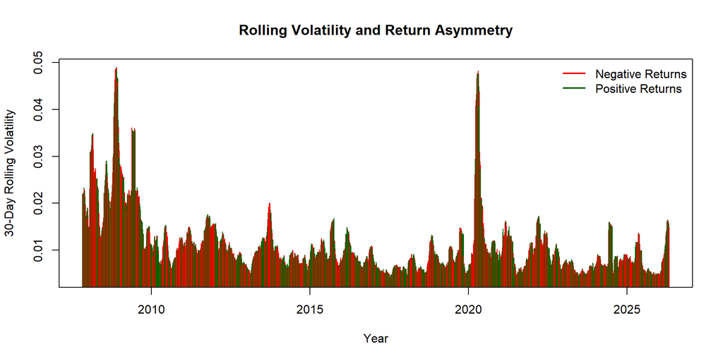

**Leverage Effect Correlation:**  
Correlation between lagged returns and future squared returns = -0.014

While the present analysis does not formally estimate asymmetric volatility models, the observed behavior indicates that frameworks such as **EGARCH** or **GJR-GARCH** may provide a **more realistic representation of NIFTY 50 volatility dynamics by explicitly accounting for asymmetric risk responses.**

# 9 Discussion

## 9.1 Market efficiency and risks:

The NIFTY market behaves efficiently in terms of predicting returns, but inefficiently in terms of risk persistence. Returns exhibit limited short-term predictability. Market risk displays substantial structure and persistence, therefore risks are predictable in clusters even if returns are not. Fat tails, high kurtosis and rejection of Jarque-bera test are suggestive of the findings that extreme moves happen more often than normal models expect. Extreme market movements occur more frequently than predicted under Gaussian assumptions, indicating the presence of substantial tail risk within the index. Volatility in the NIFTY 50 is highly time-varying and persistent rather than constant.

Essentially, the findings suggest that the NIFTY 50 behaves as a largely efficient market in terms of return predictability, while simultaneously exhibiting persistent volatility dynamics and elevated exposure to extreme market events.

## 9.2 Test of stationarity:

In a non-stationary data set, relationships of data can become inconsistent since the mean can drift and volatility can change, leading to misleading statistical results.

Stationarity tests verify that the return process itself is stable enough to model meaningfully. In the context of the NIFTY 50, raw price levels exhibit strong upward trends and are inherently non-stationary. Testing stationarity on the transformed return series ensures that the observed behavior reflects genuine market dynamics rather than distortions caused by long-term price growth.

## 9.3 Volatility clustering:

Volatility clusters because financial markets do not absorb uncertainty instantly. Large shocks to the market tend to create continuing uncertainty, causing elevated risk and price fluctuations to persist across multiple trading sessions rather than disappearing immediately.

Consecutive periods of large market movements create clusters of high volatility. During stable economic periods,market fluctuations remain relatively subdued, resulting in prolonged low-volatility regimes. As a result, volatility becomes time-dependent. Persistence in market risk is what produces volatility clustering in financial return series. ACF of squared returns and ARCH test statistically captured the persistence of market risk in the NIFTY 50 returns.

# 10 Limitations

While the analysis provides strong evidence regarding the statistical behavior of NIFTY 50 returns, several limitations remain.

First, the analysis is entirely linear in nature. Techniques such as the autocorrelation function and Ljung–Box diagnostics detect only linear dependence structures. The absence of strong linear autocorrelation therefore does not eliminate the possibility of non-linear predictability in returns. More advanced approaches such as copula-based dependence modeling or mutual information analysis would be required to examine non-linear relationships.

Second, although the ARCH LM test confirms the presence of conditional heteroscedasticity, the analysis does not formally estimate a conditional volatility model. Extensions using GARCH(1,1), EGARCH, or GJR-GARCH specifications would allow direct estimation of volatility persistence parameters and asymmetric volatility responses.

Third, the leverage effect is demonstrated primarily through rolling volatility behavior and lagged return-volatility correlations rather than through formal asymmetric volatility estimation. A fully specified EGARCH or GJR-GARCH framework would provide statistically testable asymmetry parameters and more rigorous measurement of downside volatility amplification.

Despite these limitations, the analysis successfully captures several major stylized facts of financial returns, including fat tails, volatility clustering, heteroscedasticity, and asymmetric risk behavior.

# 11 Conclusion

This analysis examined the statistical structure and volatility dynamics of NIFTY 50 log returns using a range of econometric and time-series diagnostics. The findings indicate that while short-term return direction remains largely unpredictable and broadly consistent with weak-form market efficiency, market risk itself evolves in a highly persistent and structured manner.

The return distribution exhibits substantial excess kurtosis and pronounced tail behavior, implying that extreme market movements occur significantly more frequently than predicted under Gaussian assumptions. Stationarity testing confirmed that the transformed log return series is suitable for time-series analysis, while autocorrelation diagnostics showed that linear dependence in raw returns remains economically weak despite statistical sensitivity arising from the large sample size.

A central result of the analysis emerges from the Ljung–Box diagnostics applied separately to returns and squared returns. While raw returns display minimal economically meaningful autocorrelation, squared returns exhibit strong serial dependence across time. This asymmetry demonstrates that although market direction itself remains difficult to forecast consistently, volatility and market risk evolve in persistent and predictable clusters. The findings therefore illustrate one of the defining stylized facts of financial markets: returns are approximately unpredictable, but risk is not.

Collectively, the results demonstrate that the NIFTY 50 exhibits many of the core empirical characteristics observed in global equity markets, including heavy tails, volatility clustering, conditional heteroscedasticity, regime-dependent volatility behavior, and asymmetric risk responses. The analysis further highlights the limitations of constant-variance Gaussian frameworks and reinforces the relevance of conditional volatility models for understanding financial market risk dynamics.

# 12 References

**Black, F. (1976).** *Studies of Stock Price Volatility Changes.* Proceedings of the 1976 Meetings of the American Statistical Association, 177–181.

**Cont, R. (2001).** *Empirical Properties of Asset Returns: Stylized Facts and Statistical Issues.* Quantitative Finance, 1(2), 223–236.

**Engle, R. F. (1982).** *Autoregressive Conditional Heteroscedasticity with Estimates of the Variance of United Kingdom Inflation.* Econometrica, 50(4), 987–1007.

**Fama, E. F. (1970).** *Efficient Capital Markets: A Review of Theory and Empirical Work.* Journal of Finance, 25(2), 383–417.

**Jarque, C. M., & Bera, A. K. (1987).** *A Test for Normality of Observations and Regression Residuals.* International Statistical Review, 55(2), 163–172.

**Ljung, G. M., & Box, G. E. P. (1978).** *On a Measure of Lack of Fit in Time Series Models.* Biometrika, 65(2), 297–303.

**Mandelbrot, B. (1963).** *The Variation of Certain Speculative Prices.* Journal of Business, 36(4), 394–419.